# R_markdown_team8

2023-09-12

Loading the ‘tidyverse’ package

Downloading the datasets (meran)

reading the data set: title_basics (meran)

reading the data set: title_ratings (Lex)

**This dataset can be used to exlore and analyze the rating of the movies and series on IMDB**

**The datasets are already have been downloaded so now we are going to read the dataset**

```r
title_ratings <- read_tsv("../../data/dataset1/title.ratings.tsv.gz")
```

*now we are going to look at the dataset*

```r
view(title_ratings)
```

**explaining the dataset** column 1: tconst *this is the identifier, each cell represents 1 serie/film* column2: averageRating *this is the averga rating the serie/film got* column 3:num_votes *This is the number of votes that contributed to the rating of the series or movie*

**summary statistics about the variables : average rating and number of votes**

```r
summary(title_ratings$averageRating)
```

```
##    Min. 1st Qu.  Median    Mean 3rd Qu.    Max.
##   1.000   6.200   7.200   6.959   7.900  10.000
```

```r
summary(title_ratings$numVotes)
```

```
##    Min. 1st Qu.  Median    Mean 3rd Qu.    Max.
##       5      11      26    1040     101 2795962
```

**A histogram with the distribution of the averga ratings**

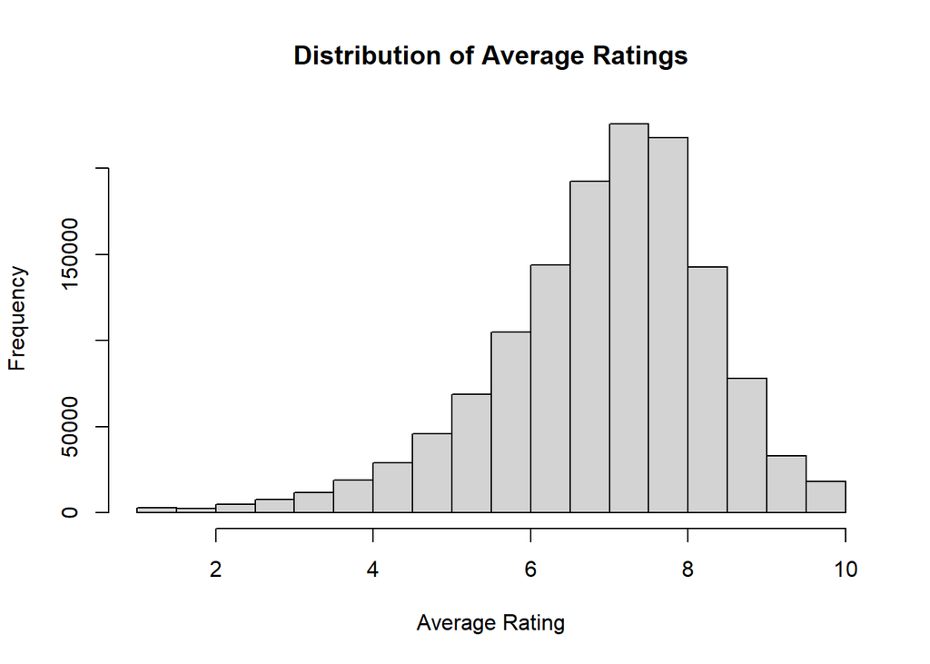

```r
hist(title_ratings$averageRating, main = "Distribution of Average Ratings", xlab = "Average Rating")
```

**Boxplot number of votes** #I do not know if this is really valuable so i want you opinions on this

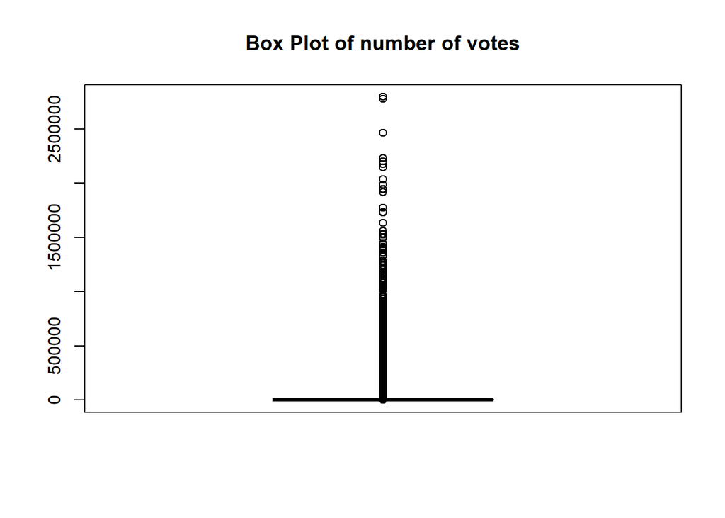

```r
boxplot(title_ratings$numVotes, main = "Box Plot of number of votes")
```

**scatter plot of the relationship between the average rating and the nuber of votes**

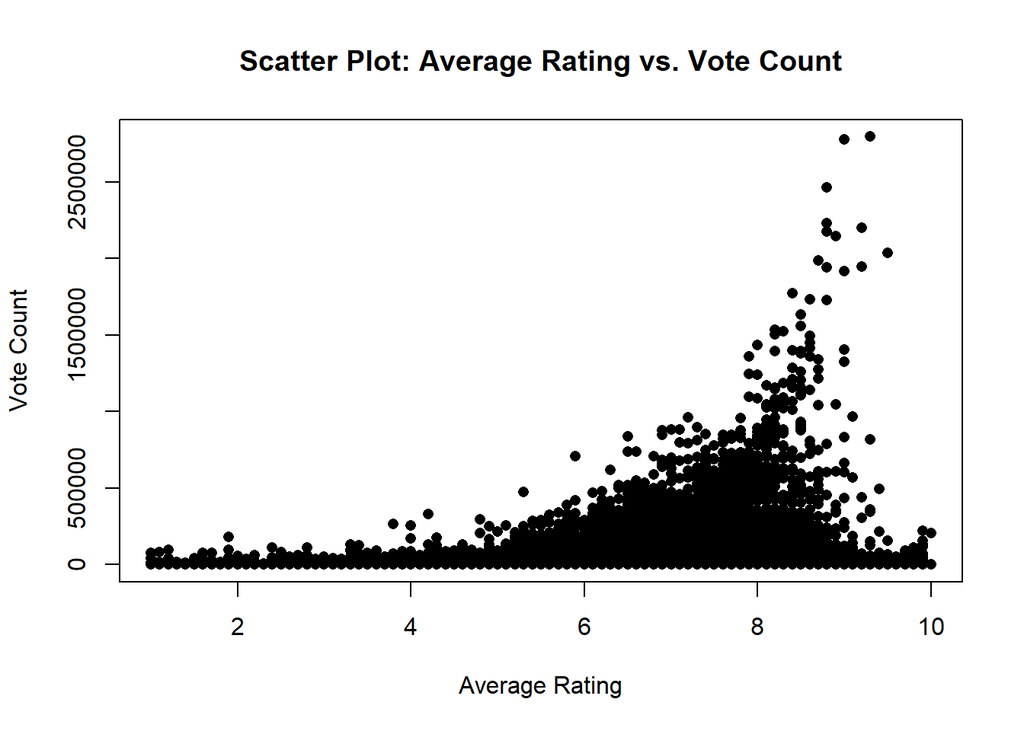

```r
plot(title_ratings$averageRating, title_ratings$numVotes, main = "Scatter Plot: Average Rating vs. Vote Count",
     xlab = "Average Rating", ylab = "Vote Count", pch = 16, col = "black")
```

**This was the information of for the data set title_ratings**

reading the data set: title_basics_ratings (Thomas)

reading the data set: name_basics (Floris)